# NON LINEAR REGRESSION MODELS

# Objective

This homework sheet will help reviewing the basic concepts associated with non-linear models. Please review the lectures, suggested readings, and additional resources *before* getting started on the HW.

**Some questions in this assignment will require you to conduct independent research beyond the material covered in the recorded content.**

**Some of the libraries / links mentioned in APPLIED questions are only for your reference. Unless specifically indicated, feel free to utilise any Python library of your choice to carry out the assignment questions**

PYGAM REFERENCE LINK:

https://pygam.readthedocs.io/en/latest/notebooks/tour_of_pygam.html

STATSMODELS REFERENCE LINK:

https://www.statsmodels.org/dev/glm.html

PATSY REFERENCE LINK:

https://patsy.readthedocs.io/en/latest/

The following website has access to the relevant datasets from the recommended textbook: https://book.huihoo.com/introduction-to-statistical-learning/data.html

Marks Distribution

| Question | Marks |
| --- | --- |
| 1a | 0.5 |
| 1b | 0.5 |
| 1c | 0.5 |
| 1d | 0.5 |
| 1e | 0.5 |
| 2 | 1 |
| 3 | 1 |
| 4 | 1 |
| 5a | 0.5 |
| 5b | 0.5 |
| 5c | 0.5 |
| 6a | 2 |
| 6b | 1 |
| 7a | 1 |
| 7b | 2 |
| 7c | 1 |
| 7d | 1 |

# Conceptual

## Question 1

Suppose that a curve $\hat{g}$ is computed to smoothly fit a set of `n` points using the following formula:

$$ \hat{g} = \arg\min_{g}(\sum_{i=1}^n (y_i - g(x_i))^2 + \lambda \int [g^{(m)} (x)]^2 dx ) $$ where $g^{(m)}$ represents the $m^{th}$ derivative of $g$ (and $g^{(0)} = g$. Provide a description (or sketch) of $\hat{g}$ in each of the following scenarios. where $g^{(m)}$ represents the m th derivative of g

(a) $\lambda$ = $\infty$, $m = 0$.

**ANSWER**

1. When $\lambda=\infty$ and m=0, the regularization term $\lambda \int [g^{(m)} (x)]^2 dx )$ dominates and the first term can be neglected.
2. Then the given equation reduces to $ \arg\min_{g}\lambda \int [g(x)]^2 dx $ . To minimize this term with $\lambda =\infty$, g(x) must be equal to zero.
3. Hence, $\hat g = 0$ when $\lambda=\infty$ and m=0

(b) $\lambda$ = $\infty$, $m = 1$.

**ANSWER**

1. When $\lambda=\infty$ and m=1, the regularization term $\lambda \int [g^{(m)} (x)]^2 dx )$ dominates and the first term can be neglected.
2. Then the given equation reduces to $ \arg\min_{g}\lambda \int [g^{1}(x)]^2 dx $ . To minimize this term with $\lambda =\infty$, $g^{1}(x)$ must be equal to zero.
3. Therefore, $g^{1}(x)=g'(x)=0$. This implies that g(x) is a constant function as derivative of a constant function is zero
4. Hence, g(x) is a constant c. $\hat g = c$ when $\lambda=\infty$ and m=1.

(c) $\lambda$ = $\infty$, $m = 2$.

**ANSWER**

1. When $\lambda=\infty$ and m=2, the regularization term $\lambda \int [g^{(m)} (x)]^2 dx )$ dominates and the first term can be neglected.
2. Then the given equation reduces to $ \arg\min_{g}\lambda \int [g^{2}(x)]^2 dx $ . To minimize this term with $\lambda =\infty$, $g^{2}(x)$ must be equal to zero.
3. Therefore, $g^{2}(x)=g"(x)=0$. This implies that g'(x) is a constant function as derivative of a constant function is zero. g'(x) = c implies that g(x) is a linear function of x.
4. Hence, g'(x) = c implies that $g(x) = cx + d$ when $\lambda=\infty$ and m=2.

(d) $\lambda$ = $\infty$, $m = 3$.

**ANSWER**

1. When $\lambda=\infty$ and m=3, the regularization term $\lambda \int [g^{(m)} (x)]^2 dx )$ dominates and the first term can be neglected.
2. Then the given equation reduces to $ \arg\min_{g}\lambda \int [g^{3}(x)]^2 dx $ . To minimize this term with $\lambda =\infty$, $g^{3}(x)$ must be equal to zero.
3. Therefore, $g^{3}(x)=0$. This implies that $g^{2}(x)=g"(x)$ is a constant function as derivative of a constant function is zero. g"(x) = c implies that g'(x) is a linear function of x and g(x) is a quadratic function of x.
4. g"(x) = c implies that $g'(x) = cx + d$. $g'(x) = cx+d$ implies that $g(x) = cx^{2} + dx + e $ when $\lambda=\infty$ and m=3.

(e) $\lambda$ = 0, $m = 3$.

**ANSWER**

1. When $\lambda$ = 0, $m = 3$, the regularization term becomes zero or vanishes.
2. Then the given equation reduces to $\arg\min_{g}(\sum_{i=1}^n (y_i - g(x_i))^2)$. The problem reduces to finding $\hat g$ that minimizes the residual sum of squares $\sum_{i=1}^n (y_i - g(x_i))^2$.
3. This implies that $\hat g $ should interpolate each and every $y_{i}$. It is equivalent to finding the ordinary least squares(OLS) fit for linear regression.

## Question 2

For (1) step functions, (2) local regression, and (3) GAMs: provide one situation when using that particular model is advantageous. For instance, “GAMs is likely the preferred option when the question I’m interested in addressing involves…”.

**ANSWER**

1. Step functions can be used in scenarios where we do not want fit a single non-linear function on the entire range of X. It is mainly advantageous when categorical predictors are involved in predicting the response. Step-functions are preferred when we want to effectively capture a sudden change in the response based on the impact of different levels of predictors. For instance, step-functions can be used to predict the response wage based on the different levels or categories of age. Categorical predictors can also be created by binning the continuous predictor values and step-function approach can be carried out to predict the response.
2. Local regression can be used in scenarios where there is a need to fit a flexible non-linear function. It involves computing the fit a target point using only the neighbouring observations. Here, weighted least squares linear regression is preformed at each target point by selecting the neighbouring points. It is preferred in scenarios where we want to predict the response at a point based on the impact of the points nearby. For instance, it can be used to predict the interest rates on a stock based on the stock prices, exchange rates, and other economic indicators. We get good estimates of the interest rates at a given time using local regression because the values are impacted mainly by the predictor values in recent times.
3. GAMs can be used in scenarios where the response is estimated using non-linear functions of each of the variables or predictors while maintaining additivity. In GAMs a separate non-linear function($f_{j}$) is calculated for each predictor($X_{j}$) and then all are added together. It also maintains interpretability. GAMs are preferred in scenarios where we want to capture non-linear relationships between the predictors and the response, and to examine the effect of each $X_{j}$ on Y individually while holding all of the other variables fixed. For example, they can be used to predict the health of an individual based on different variables such as temperature, dust level, air pollution and carbon emissions.

## Question 3

Define the following types of smooth functions from PYGAM library (https://pygam.readthedocs.io/en/latest/notebooks/tour_of_pygam.html ) and list at least one relevant potential use:

a) l() linear terms

b) s() spline terms

c) f() factor terms

d) te() Tensor product interaction terms

**ANSWER**

a) l() linear terms: This function is used to model a simple linear relation between the predictor variable and the response. By default it has l2 ridge penalty. The main arguments of the function are feature index, tuning or smoothing parameter and type of smoothing penalty(L2, derivative etc.,). For example one potential use case is to predict the house price based only on the number of rooms.

b) s() spline terms: This function is used when the relationship between the predictor variable and the response is non-linear. They can be used to fit various non-linear functions. By default it has a penalty on its 2nd derivative and uses 20 splines. The main arguments of the function are feature index, tuning or smoothing parameter, type of smoothing penalty(L2, derivative etc.,), order of the spline and type of basis functions. For example one potential use case is to model the non-linear relationship between the risk of diabetes and hours of exercise. Another use case is to predict the risk of lung allergy based on the time exposed to pollutants.

c) f() factor terms: This function is used to model the relationship between categorical predictors and the response. By default it has l2 ridge penalty. The main arguments of the function are feature index, tuning or smoothing parameter, type of smoothing penalty and type of encoding for feature categories(one-hot). For example one potential use case is to predict the income based on the gender. The factor terms can effectively capture the underlying relation between the income and the categories of gender.

d) te() Tensor product interaction terms: This function is used to model the underlying interactions between two or more predictors and the response. The main arguments of the function are feature index, tuning or smoothing parameter, type of smoothing penalty, number of splines and order of the spline. For example one potential use case is to model the effect of interaction between temperature and humidity and crop yield.

## Question 4

Briefly explain what spatial and temporal autocorrelation are? List one way in which GAMs could help to account for this (e.g. indicate the type of smooth function you would use or potential types of correlation structures).

**ANSWER**

1. Spatial autocorrelation is the correlation between points or observations at different locations in space. Points closer to each other are more similar or correlated than the points that are farther apart. GAMs account for spatial autcorrelation by adding latitude and longitude as smoothing terms. Thin-plate spline function in GAM is used as a smooth function to capture the variability in space or to account for spatial autocorrelation.
2. Temporal autocorrelation is the correlation between observations at different points in time. Observations that are closer in time are more similar or correlated than those that are farther apart. Cyclic cubic regression splines are used as smoothing terms in GAMs to account for the temporal autocorrelation. Apart from this, moving average correlation structure is also used to account for temporal autocorrelation.

## Question 5

Consider two curves $\hat{g}1$ and $\hat{g}2$, defined by

$$ \hat{g}1 = \arg\min_{g}(\sum_{i=1}^n (y_i - g(x_i))^2 + \lambda \int [g^{(3)} (x)]^2 dx ) $$

$$ \hat{g}2 = \arg\min_{g}(\sum_{i=1}^n (y_i - g(x_i))^2 + \lambda \int [g^{(4)} (x)]^2 dx ) $$

where $g^{(m)}$ represents the $m^{th}$ derivative of $g$. Now, answer the following questions (and include a brief explanation):

a) As $\lambda \rightarrow \infty$, will $\hat{g}1$ or $\hat{g}2$ have smaller training RSS?

**ANSWER**

1. When $\lambda=\infty$, only the second terms of $\hat g1$ and $\hat g2$ dominate and the first terms can be ignored. The equations reduce to $\arg\min_{g} \lambda \int [g^{(3)} (x)]^2 dx$ and $\arg\min_{g} \lambda \int [g^{(4)} (x)]^2 dx$.
2. In case of $\hat g1$, the equation reduces to $\arg\min_{g} \lambda \int [g^{(3)} (x)]^2 dx$. To minimize this term with $\lambda=\infty$, $g^{3}(x)$ must be zero. Therefore, $g^{3}(x)=0$. This implies that $g^{2}(x)=g"(x)$ is a constant function as derivative of a constant function is zero. g"(x) = c implies that g'(x) is a linear function of x and g(x) is a quadratic function of x. g"(x) = c implies that $g'(x) = cx + d$. $g'(x) = cx+d$ implies that $g(x) = cx^{2} + dx + e$. Hence, $\hat g1$ is a quadratic polynomial.
3. In case of $\hat g2$, the equation reduces to $\arg\min_{g} \lambda \int [g^{(4)} (x)]^2 dx$. To minimize this term with $\lambda=\infty$, $g^{4}(x)$ must be zero. Therefore, $g^{4}(x)=0$. This implies that $g^{3}(x)$ is a constant function as derivative of a constant function is zero. $g^{3}(x)=c$ implies that g"(x) is a linear function of x and g'(x) is a quadratic function of x. $g"(x) = cx + d$ implies that $g'(x) = cx^{2} + dx + e$. $g'(x) = cx^{2} + dx + e$ implies that $g(x) = cx^{3} + dx^{2} + ex + f$. Hence, $\hat g2$ is a cubic polynomial.
4. $\hat g2$ is more flexible than $\hat g1$ as $\hat g2$ is a cubic polynomial and $\hat g1$ is a quadratic polynomial. $\hat g2$ being a cubic polynomial can fit the training data better than $\hat g1$(quadratic) and can capture the underlying patterns more effectively than $\hat g1$. Hence, $\hat g2$ has smaller training RSS than $\hat g1$.

b) As $\lambda \rightarrow \infty$, will $\hat{g}1$ or $\hat{g}2$ have smaller test RSS?

**ANSWER**

1. We cannot determine whether $\hat g1$ or $\hat g2$ has smaller test RSS because we do not know the information regarding the degree of non-linearity in the true relationship between the predictor and the response.
2. If the true relation between predictor and response is closer to a quadratic relationship then $\hat g1$ has lower test RSS.
3. If the true relation between predictor and response is closer to a cubic relationship then $\hat g2$ has lower test RSS.

c) For $\lambda= 0$, will $\hat{g}1$ or $\hat{g}2$ have smaller training RSS?

**ANSWER**

1. When $\lambda=0$, both $\hat g1$ and $\hat g2$ reduce to $\arg\min_{g}(\sum_{i=1}^n (y_i - g(x_i))^2)$. The problem reduces to minimizing the residual sum of squares $\sum_{i=1}^n (y_i - g(x_i))^2$.
2. Both $\hat g1$ and $\hat g2$ are same and they will interpolate each and every $y_{i}$. Hence, both will have the same training RSS.

APPLIED

## Question 6

This question relates to the `College` data set.

pre process the data if required

```python
import numpy as np
import pandas as pd
import matplotlib.pyplot as plt
from matplotlib.pyplot import subplots
import statsmodels.api as sm
from statsmodels.gam.api import GLMGam, BSplines
from sklearn.model_selection import train_test_split
from sklearn.preprocessing import StandardScaler, MinMaxScaler
from sklearn.metrics import r2_score, mean_squared_error, mean_absolute_error
from ISLP.models import (summarize,poly,ModelSpec as MS)
from statsmodels.stats.anova import anova_lm
from pygam import s,f, LinearGAM
from ISLP.models import bs, ns
from ISLP.pygam import (approx_lam,degrees_of_freedom,plot as plot_gam,anova as anova_gam)
```

```python
org = pd.read_csv('./College.csv')
org.head()
```

|  | Unnamed: 0 | Private | Apps | Accept | Enroll | Top10perc | Top25perc | F.Undergrad | P.Undergrad | Outstate | Room.Board | Books | Personal | PhD | Terminal | S.F.Ratio | perc.alumni | Expend | Grad.Rate |
| --- | --- | --- | --- | --- | --- | --- | --- | --- | --- | --- | --- | --- | --- | --- | --- | --- | --- | --- | --- |
| 0 | Abilene Christian University | Yes | 1660 | 1232 | 721 | 23 | 52 | 2885 | 537 | 7440 | 3300 | 450 | 2200 | 70 | 78 | 18.1 | 12 | 7041 | 60 |
| 1 | Adelphi University | Yes | 2186 | 1924 | 512 | 16 | 29 | 2683 | 1227 | 12280 | 6450 | 750 | 1500 | 29 | 30 | 12.2 | 16 | 10527 | 56 |
| 2 | Adrian College | Yes | 1428 | 1097 | 336 | 22 | 50 | 1036 | 99 | 11250 | 3750 | 400 | 1165 | 53 | 66 | 12.9 | 30 | 8735 | 54 |
| 3 | Agnes Scott College | Yes | 417 | 349 | 137 | 60 | 89 | 510 | 63 | 12960 | 5450 | 450 | 875 | 92 | 97 | 7.7 | 37 | 19016 | 59 |
| 4 | Alaska Pacific University | Yes | 193 | 146 | 55 | 16 | 44 | 249 | 869 | 7560 | 4120 | 800 | 1500 | 76 | 72 | 11.9 | 2 | 10922 | 15 |

```python
df = org.copy()
df.info()
```

```
<class 'pandas.core.frame.DataFrame'>
RangeIndex: 777 entries, 0 to 776
Data columns (total 19 columns):
 #   Column       Non-Null Count  Dtype
---  ------       --------------  -----
 0   Unnamed: 0   777 non-null    object
 1   Private      777 non-null    object
 2   Apps         777 non-null    int64
 3   Accept       777 non-null    int64
 4   Enroll       777 non-null    int64
 5   Top10perc    777 non-null    int64
 6   Top25perc    777 non-null    int64
 7   F.Undergrad  777 non-null    int64
 8   P.Undergrad  777 non-null    int64
 9   Outstate     777 non-null    int64
 10  Room.Board   777 non-null    int64
 11  Books        777 non-null    int64
 12  Personal     777 non-null    int64
 13  PhD          777 non-null    int64
 14  Terminal     777 non-null    int64
 15  S.F.Ratio    777 non-null    float64
 16  perc.alumni  777 non-null    int64
 17  Expend       777 non-null    int64
 18  Grad.Rate    777 non-null    int64
dtypes: float64(1), int64(16), object(2)
memory usage: 115.5+ KB
```

```python
df['Private'] = df['Private'].map({'Yes':1,'No':0})
df.columns = df.columns.str.replace('.','_')
df = df.rename(columns={'Unnamed: 0':'Name'})
df.head()
```

|  | Name | Private | Apps | Accept | Enroll | Top10perc | Top25perc | F_Undergrad | P_Undergrad | Outstate | Room_Board | Books | Personal | PhD | Terminal | S_F_Ratio | perc_alumni | Expend | Grad_Rate |
| --- | --- | --- | --- | --- | --- | --- | --- | --- | --- | --- | --- | --- | --- | --- | --- | --- | --- | --- | --- |
| 0 | Abilene Christian University | 1 | 1660 | 1232 | 721 | 23 | 52 | 2885 | 537 | 7440 | 3300 | 450 | 2200 | 70 | 78 | 18.1 | 12 | 7041 | 60 |
| 1 | Adelphi University | 1 | 2186 | 1924 | 512 | 16 | 29 | 2683 | 1227 | 12280 | 6450 | 750 | 1500 | 29 | 30 | 12.2 | 16 | 10527 | 56 |
| 2 | Adrian College | 1 | 1428 | 1097 | 336 | 22 | 50 | 1036 | 99 | 11250 | 3750 | 400 | 1165 | 53 | 66 | 12.9 | 30 | 8735 | 54 |
| 3 | Agnes Scott College | 1 | 417 | 349 | 137 | 60 | 89 | 510 | 63 | 12960 | 5450 | 450 | 875 | 92 | 97 | 7.7 | 37 | 19016 | 59 |
| 4 | Alaska Pacific University | 1 | 193 | 146 | 55 | 16 | 44 | 249 | 869 | 7560 | 4120 | 800 | 1500 | 76 | 72 | 11.9 | 2 | 10922 | 15 |

```python
df_normalized = df.copy()
norm_cols = df.columns.difference(['Name', 'Private', 'Outstate'])

scaler = StandardScaler()
df_normalized[norm_cols] = scaler.fit_transform(df_normalized[norm_cols])
df_normalized.head()
```

|  | Name | Private | Apps | Accept | Enroll | Top10perc | Top25perc | F_Undergrad | P_Undergrad | Outstate | Room_Board | Books | Personal | PhD | Terminal | S_F_Ratio | perc_alumni | Expend | Grad_Rate |
| --- | --- | --- | --- | --- | --- | --- | --- | --- | --- | --- | --- | --- | --- | --- | --- | --- | --- | --- | --- |
| 0 | Abilene Christian University | 1 | -0.346882 | -0.321205 | -0.063509 | -0.258583 | -0.191827 | -0.168116 | -0.209207 | 7440 | -0.964905 | -0.602312 | 1.270045 | -0.163028 | -0.115729 | 1.013776 | -0.867574 | -0.501910 | -0.318252 |
| 1 | Adelphi University | 1 | -0.210884 | -0.038703 | -0.288584 | -0.655656 | -1.353911 | -0.209788 | 0.244307 | 12280 | 1.909208 | 1.215880 | 0.235515 | -2.675646 | -3.378176 | -0.477704 | -0.544572 | 0.166110 | -0.551262 |
| 2 | Adrian College | 1 | -0.406866 | -0.376318 | -0.478121 | -0.315307 | -0.292878 | -0.549565 | -0.497090 | 11250 | -0.554317 | -0.905344 | -0.259582 | -1.204845 | -0.931341 | -0.300749 | 0.585935 | -0.177290 | -0.667767 |
| 3 | Agnes Scott College | 1 | -0.668261 | -0.681682 | -0.692427 | 1.840231 | 1.677612 | -0.658079 | -0.520752 | 12960 | 0.996791 | -0.602312 | -0.688173 | 1.185206 | 1.175657 | -1.615274 | 1.151188 | 1.792851 | -0.376504 |
| 4 | Alaska Pacific University | 1 | -0.726176 | -0.764555 | -0.780735 | -0.655656 | -0.596031 | -0.711924 | 0.009005 | 7560 | -0.216723 | 1.518912 | 0.235515 | 0.204672 | -0.523535 | -0.553542 | -1.675079 | 0.241803 | -2.939613 |

a) Fit a GAM on the training data, using out-of-state tuition as the response and only subset of features as the predictors ( Select 'private', 'Room.Board' , 'PhD' , 'perc.alumni' , 'Expend' , 'Grad.rate' ) Plot the results and briefly explain your findings

**ANSWER**

```python
X = df_normalized[['Private','Room_Board','PhD','perc_alumni','Expend','Grad_Rate']]
y = df_normalized['Outstate']

X_train, X_test, y_train, y_test = train_test_split(X, y, test_size=0.2, random_state=12345)
```

[output not shown]

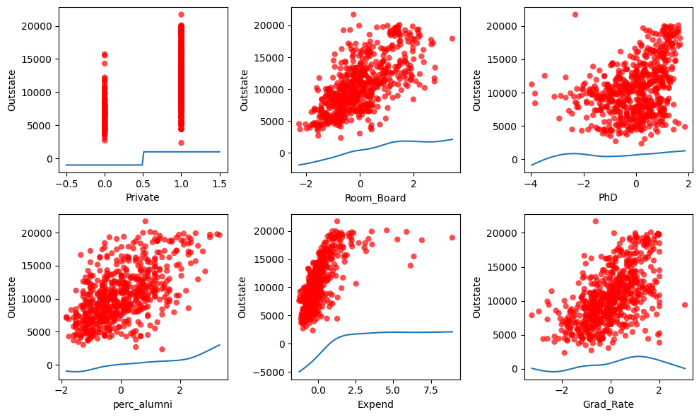

```
LinearGAM
=============================================== ==========================================================
Distribution:                        NormalDist Effective DoF:                                     27.9124
Link Function:                     IdentityLink Log Likelihood:                                 -9922.9218
Number of Samples:                          621 AIC:                                            19903.6683
                                                AICc:                                           19906.5946
                                                GCV:                                           3775334.609
                                                Scale:                                        3471167.0364
                                                Pseudo R-Squared:                                   0.7967
==========================================================================================================
Feature Function                  Lambda               Rank         EDoF         P > x        Sig. Code
================================= ==================== ============ ============ ============ ============
f(0)                              [22.1222]            2            1.9          1.11e-16     ***
s(1)                              [22.1222]            20           6.1          6.53e-12     ***
s(2)                              [22.1222]            20           6.1          3.37e-01
s(3)                              [22.1222]            20           5.6          2.53e-04     ***
s(4)                              [22.1222]            20           3.9          1.11e-16     ***
s(5)                              [22.1222]            20           4.3          2.59e-05     ***
intercept                                              1            0.0          1.11e-16     ***
==========================================================================================================
Significance codes:  0 '***' 0.001 '**' 0.01 '*' 0.05 '.' 0.1 ' ' 1

WARNING: Fitting splines and a linear function to a feature introduces a model identifiability problem
         which can cause p-values to appear significant when they are not.

WARNING: p-values calculated in this manner behave correctly for un-penalized models or models with
         known smoothing parameters, but when smoothing parameters have been estimated, the p-values
         are typically lower than they should be, meaning that the tests reject the null too readily.
None
```

```python
gam = LinearGAM(f(0) + s(1) + s(2) + s(3) + s(4) + s(5))

# Fit the GAM model
gam.fit(X_train, y_train)
gam = gam.gridsearch(X_train, y_train,lam= np.logspace(-3, 3, 30))
# Plot the results
plt.figure(figsize=(10, 6))

# Plot each predictor against the response variable
for i, term in enumerate(gam.terms):
    if term.isintercept:
        continue
    plt.subplot(2, 3, i+1)
    XX = gam.generate_X_grid(term=i)
    plt.plot(XX[:, i], gam.partial_dependence(term=i, X=XX))
    plt.scatter(X_train.iloc[:, i], y_train, facecolor='red', edgecolors='none', alpha=0.7)
    #plt.title(X_train.columns[i])
    plt.xlabel(X_train.columns[i])
    plt.ylabel('Outstate')

plt.tight_layout()
plt.show()

print(gam.summary())
```

1. The above plots illustrate the relationship between each predictor and the response Outstate which is out-of-state tuition.
2. The effective degrees of freedom are 27.9124.
3. The tuning parameter obtained by grid search method is $\lambda=22.1222$.
4. Factors term f() is used to model the relationship between the categorical variable Private and the response Outstate. f() is used to model the relationship between categorical predictors and the response.

b) For which variables, if any, is there evidence of a non-linear relationship with the response?

**ANSWER**

## Question 7

Answer the questions below using the following dataset (WEEK3_Q7 CSV provided with the learner template):

a) Only by inspecting the plots shown below: Is there any temporal or spatial trend in the response variable `richness`?

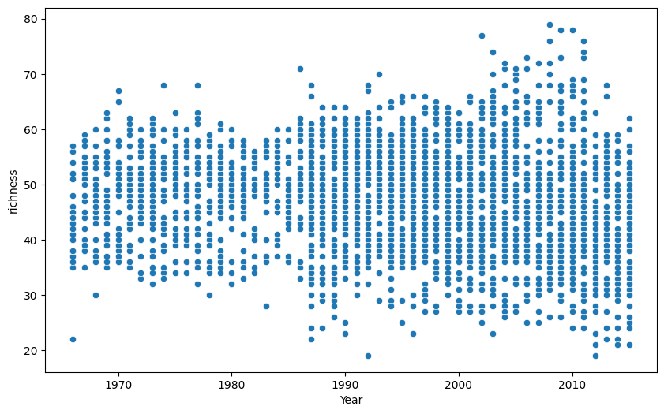

```python
import seaborn as sns
df2 = pd.read_csv('./WEEK3_Q7.csv')
sns.scatterplot(x=df2.Year,y=df2.richness)
```

b) Now, fit a Poisson GAM with the following structure `E(richness) = exp(f(year))*exp(g(location))`. Note that location is actually two features: `Longitude` and `Latitude.` Name this model `M1.` Plot the model, get the `summary` of `M1`, and answer: Is there evidence for effects of location and year?

**ANSWER**

```python
from pygam import PoissonGAM,te,s
import numpy as np
import pandas as pd
import matplotlib.pyplot as plt
from sklearn.metrics import mean_squared_error
df2.info()
```

```
<class 'pandas.core.frame.DataFrame'>
RangeIndex: 2824 entries, 0 to 2823
Data columns (total 9 columns):
 #   Column       Non-Null Count  Dtype
---  ------       --------------  -----
 0   Year         2824 non-null   int64
 1   Route        2824 non-null   int64
 2   statenum     2824 non-null   int64
 3   richness     2824 non-null   int64
 4   abundance    2824 non-null   int64
 5   Active       2824 non-null   int64
 6   Latitude     2824 non-null   float64
 7   Longitude    2824 non-null   float64
 8   RouteTypeID  2824 non-null   int64
dtypes: float64(2), int64(7)
memory usage: 198.7 KB
```

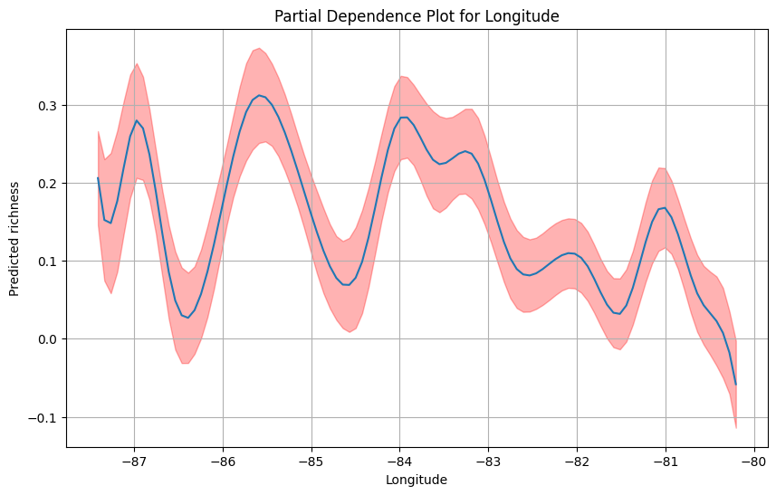

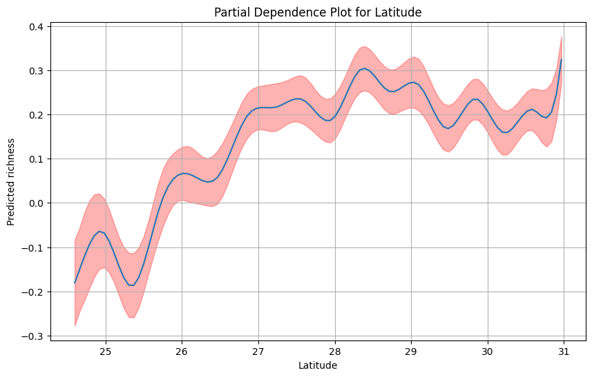

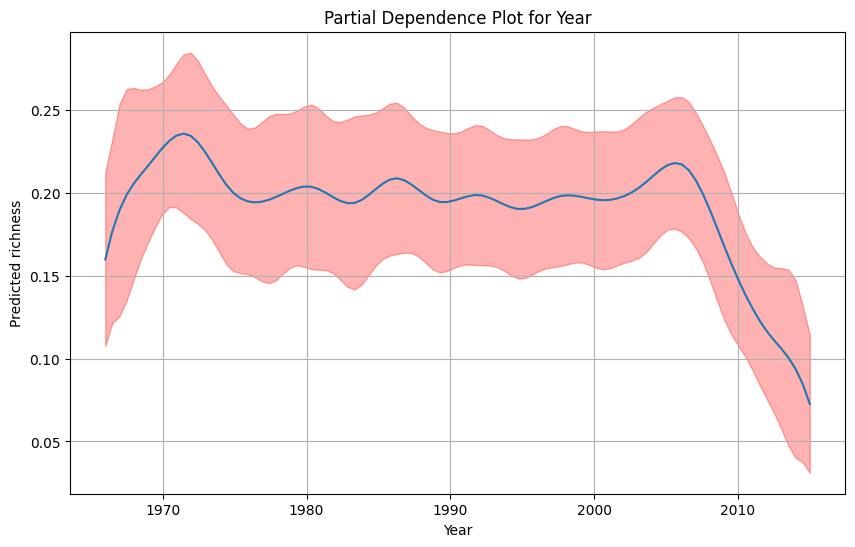

```
PoissonGAM
=============================================== ==========================================================
Distribution:                       PoissonDist Effective DoF:                                     55.6716
Link Function:                          LogLink Log Likelihood:                                 -7499.5408
Number of Samples:                         2259 AIC:                                            15110.4248
                                                AICc:                                           15113.3942
                                                UBRE:                                               3.0349
                                                Scale:                                                 1.0
                                                Pseudo R-Squared:                                   0.4581
==========================================================================================================
Feature Function                  Lambda               Rank         EDoF         P > x        Sig. Code
================================= ==================== ============ ============ ============ ============
s(0)                              [0.6]                20           19.3         0.00e+00     ***
s(1)                              [0.6]                20           17.8         0.00e+00     ***
s(2)                              [0.6]                20           18.6         1.11e-16     ***
intercept                                              1            0.0          0.00e+00     ***
==========================================================================================================
Significance codes:  0 '***' 0.001 '**' 0.01 '*' 0.05 '.' 0.1 ' ' 1

WARNING: Fitting splines and a linear function to a feature introduces a model identifiability problem
         which can cause p-values to appear significant when they are not.

WARNING: p-values calculated in this manner behave correctly for un-penalized models or models with
         known smoothing parameters, but when smoothing parameters have been estimated, the p-values
         are typically lower than they should be, meaning that the tests reject the null too readily.
None
```

```python
data = df2.copy()

X = data[['Longitude','Latitude', 'Year']]
y = data['richness']

X_train,X_test,y_train,y_test = train_test_split(X,y,test_size=0.2,random_state=54321)

M1 = PoissonGAM(s(0)+s(1)+s(2))
M1.fit(X_train,y_train)
#print(M1.summary())
#M1 = M1.gridsearch(X_train,y_train,lam=np.logspace(-3,3,20))
plt.figure()
for i, term in enumerate(M1.terms):
    if term.isintercept:
        continue

    XX = M1.generate_X_grid(term=i)
    pdep, confi = M1.partial_dependence(term=i, X=XX, width=0.95)

    # Get the feature name from the DataFrame
    feature_name = X.columns[i]

    # Plot partial dependence and confidence intervals

    plt.rcParams['figure.figsize'] = (10, 6)
    plt.plot(XX[:, i], pdep)
    plt.fill_between(XX[:, i], confi[:, 0], confi[:, 1], color='r', alpha=0.3)
    plt.title(f'Partial Dependence Plot for {feature_name}')
    plt.xlabel(feature_name)
    plt.ylabel('Predicted richness')
    plt.grid(True)
    plt.show()

print(M1.summary())
```

c) Now, fit another Poisson GAM model with the same structure as in `M1` , name this model `M2` but using interactions between Year, Latitude and Longitude

**ANSWER**

```python
M2 = PoissonGAM(te(0,1)+te(1,2)+te(0,2))
M2.fit(X_train,y_train)
#M2 = M2.gridsearch(X_train,y_train,lam=np.logspace(-3,3,20))

print(M2.summary())
```

```
PoissonGAM
=============================================== ==========================================================
Distribution:                       PoissonDist Effective DoF:                                    131.0552
Link Function:                          LogLink Log Likelihood:                                 -7278.8834
Number of Samples:                         2259 AIC:                                            14819.8773
                                                AICc:                                            14836.407
                                                UBRE:                                                2.933
                                                Scale:                                                 1.0
                                                Pseudo R-Squared:                                   0.5677
==========================================================================================================
Feature Function                  Lambda               Rank         EDoF         P > x        Sig. Code
================================= ==================== ============ ============ ============ ============
te(0, 1)                          [0.6 0.6]            100          40.3         0.00e+00     ***
te(1, 2)                          [0.6 0.6]            100          52.1         0.00e+00     ***
te(0, 2)                          [0.6 0.6]            100          38.6         0.00e+00     ***
intercept                                              1            0.0          0.00e+00     ***
==========================================================================================================
Significance codes:  0 '***' 0.001 '**' 0.01 '*' 0.05 '.' 0.1 ' ' 1

WARNING: Fitting splines and a linear function to a feature introduces a model identifiability problem
         which can cause p-values to appear significant when they are not.

WARNING: p-values calculated in this manner behave correctly for un-penalized models or models with
         known smoothing parameters, but when smoothing parameters have been estimated, the p-values
         are typically lower than they should be, meaning that the tests reject the null too readily.
None
```

d) Compare `M1` and `M2`. Note that you can use the $R^2$, AIC values, test error, among other approaches discussed in class. Which model should we select?

**ANSWER**

```python
m1_pred = M1.predict(X_test)
m1_test_error = mean_squared_error(m1_pred,y_test)


m2_pred = M2.predict(X_test)
m2_test_error = mean_squared_error(m2_pred,y_test)
m1_aic = M1.statistics_['AIC']
print(f'AIC for M1 is {m1_aic}\n')
m2_aic = M2.statistics_['AIC']
print(f'AIC for M2 is {m2_aic}\n')


print(f'Test error using M1 model is {m1_test_error}\n')
print(f'Test error using M2 model is {m2_test_error}\n')
```

```
AIC for M1 is 15110.424778491877

AIC for M2 is 14819.877266295627

Test error using M1 model is 47.03897443152673

Test error using M2 model is 39.93278685494057
```

**Therefore, M2 should be selected since it has lower test set error and lower AIC. Moreover from the above summaries it is clear that M2 has higher $R^2$ value which is preferred.**